# Homework 1

Alec Rospierski

September 7th, 2022

1. Calculate the following numerical results to three decimal places using R. [Note: Function “ln” means the natural log function]

1. $(7 - 8) + 5^3 - 5 / 6 + \sqrt{62}$
2. $\ln 3 + \sqrt 2 \sin(\pi) - e^3$
3. $\ln 5 - exp(2) + 2^3$

```r
# a
a <- (7 - 8) + (5 ^ 3) - (5 / 6) + (sqrt(62))

# b
b <- log(3) + (sqrt(2)) * sin(pi) - exp(1)^3

# c
c <- log(5) - exp(2) + 2^3

sprintf("a: %.3f", round(a, digits = 3))
```

```
## [1] "a: 131.041"
```

```r
sprintf("b: %.3f", round(b, digits = 3))
```

```
## [1] "b: -18.987"
```

```r
sprintf("c: %.3f", round(c, digits = 3))
```

```
## [1] "c: 2.220"
```

2. Create a vector named countby5 that is a sequence of 5 to 100 in steps of 5.

```r
countby5 <- seq(5, 100, by = 5)
print(countby5)
```

```
##  [1]   5  10  15  20  25  30  35  40  45  50  55  60  65  70  75  80  85  90  95
## [20] 100
```

3. Provide the missing values in rep(seq(*,* , *),* ) to create the sequence 20, 15, 15, 10, 10, 10, 5, 5, 5, 5.

```r
rep_seq <- rep(seq(20, 5, by = -5), 1:4)
print(rep_seq)
```

```
##  [1] 20 15 15 10 10 10  5  5  5  5
```

4. Solve the following system of equations using R.
   $$3x + 2y + 1z = 10 \\
   2x - 3y + 1z = -1 \\
   1x + 1y + 1z = 6$$

```r
m_a <- rbind(c(3, 2, 1), c(2, -3, 1), c(1, 1, 1))
m_b <- c(10, -1, 6)
solved <- solve(m_a, m_b)
x <- solved[1]
y <- solved[2]
z <- solved[3]
sprintf("x = %.0f :: y = %.0f :: z = %.0f", x, y, z)
```

```
## [1] "x = 1 :: y = 2 :: z = 3"
```

5. Do some exploratory analysis on the winequality-red.csv data set using R. Find the range, mean, standard deviation, distribution, etc., of the quantitative variables. Create 4 different plots to reveal interesting relationships among different variables. Make the plots self-explanatory as possible, by using appropriate title and axis labels and (if applicable) legends. Write one or two sentences to explain what information or hypothesis can be gleaned from each plot. You are recommended to conduct and document the analysis using R Markdown.

# Exploratory Data Analysis on Wine Quality Data Set

## Loading and Inspecting the Data

```r
wine_df <- read.table(file = '../week_one_tut/winequality-red.csv', sep = ';', header = T)
# change quality column to factor
wine_df$quality <- as.factor(wine_df$quality)
head(wine_df)
```

```
##   fixed.acidity volatile.acidity citric.acid residual.sugar chlorides
## 1           7.4             0.70        0.00            1.9     0.076
## 2           7.8             0.88        0.00            2.6     0.098
## 3           7.8             0.76        0.04            2.3     0.092
## 4          11.2             0.28        0.56            1.9     0.075
## 5           7.4             0.70        0.00            1.9     0.076
## 6           7.4             0.66        0.00            1.8     0.075
##   free.sulfur.dioxide total.sulfur.dioxide density   pH sulphates alcohol
## 1                  11                   34  0.9978 3.51      0.56     9.4
## 2                  25                   67  0.9968 3.20      0.68     9.8
## 3                  15                   54  0.9970 3.26      0.65     9.8
## 4                  17                   60  0.9980 3.16      0.58     9.8
## 5                  11                   34  0.9978 3.51      0.56     9.4
## 6                  13                   40  0.9978 3.51      0.56     9.4
##   quality
## 1       5
## 2       5
## 3       5
## 4       6
## 5       5
## 6       5
```

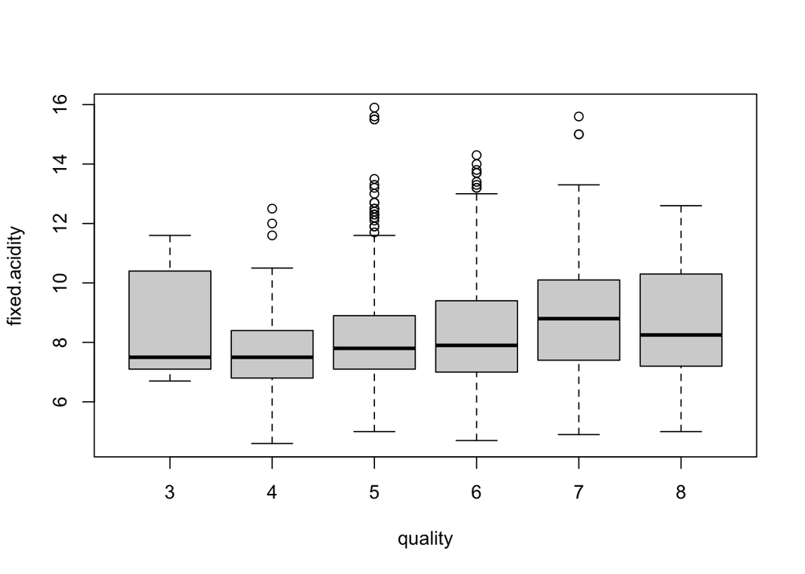

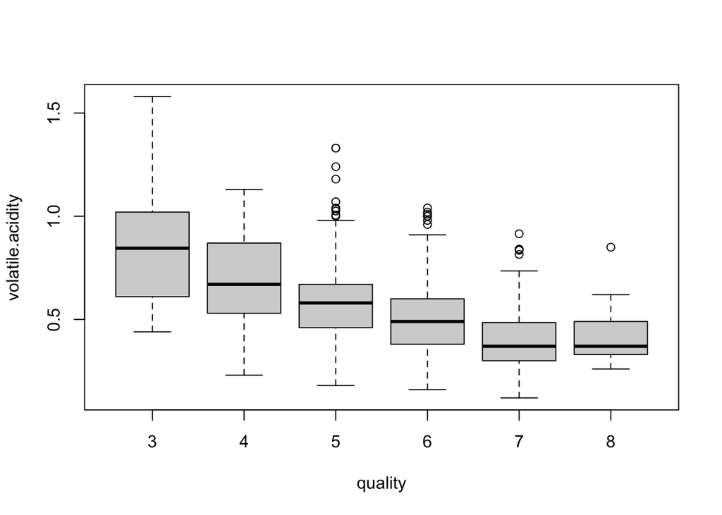

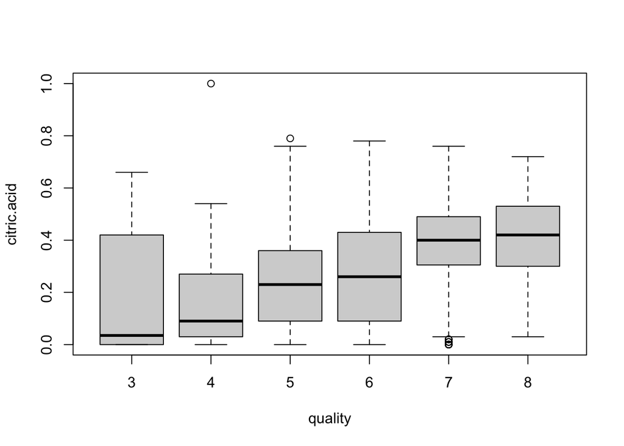

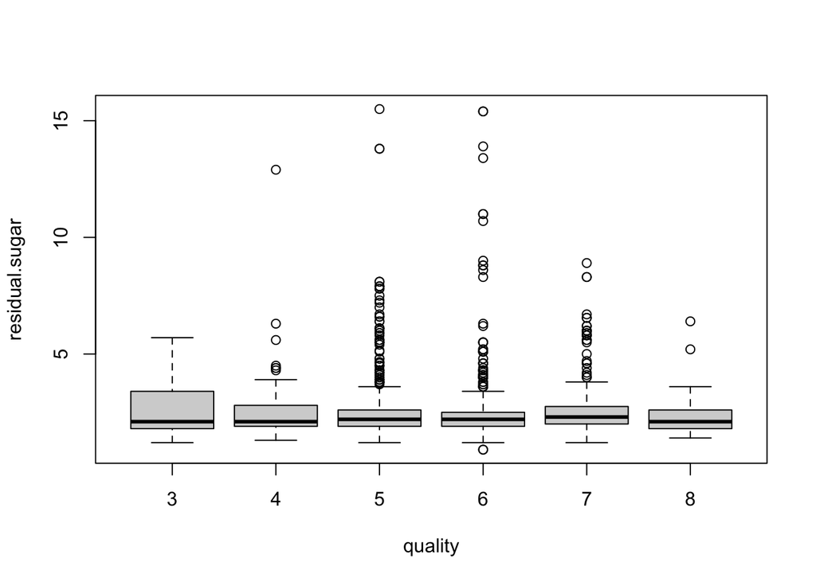

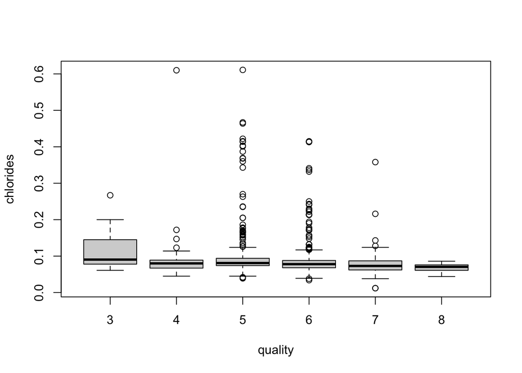

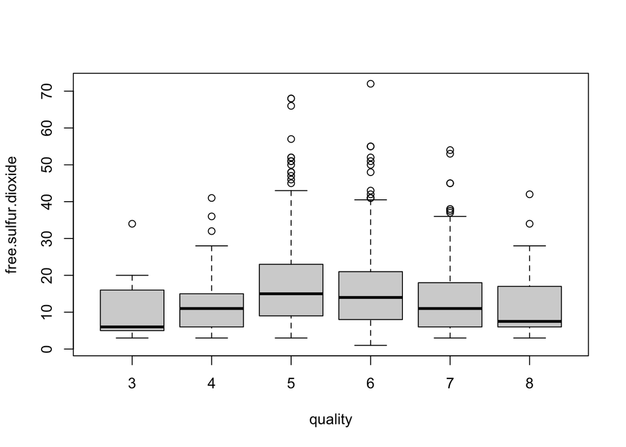

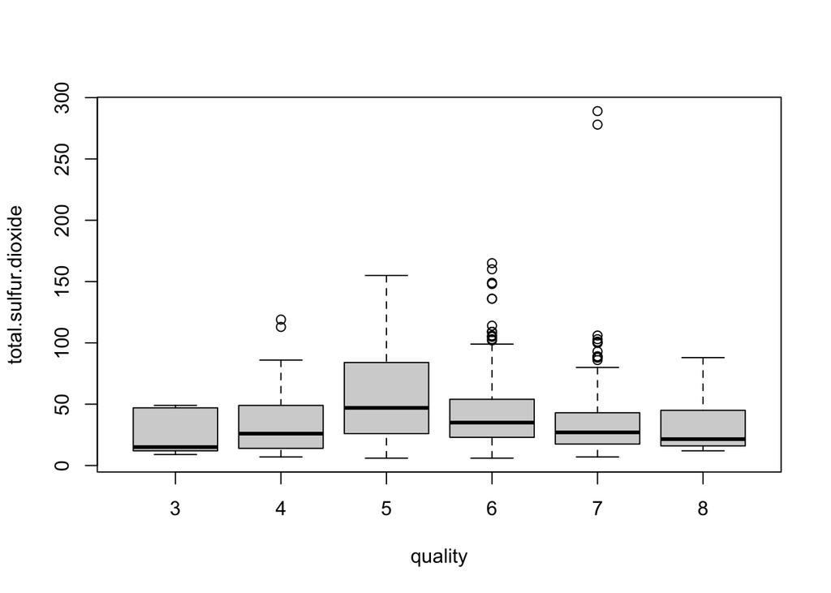

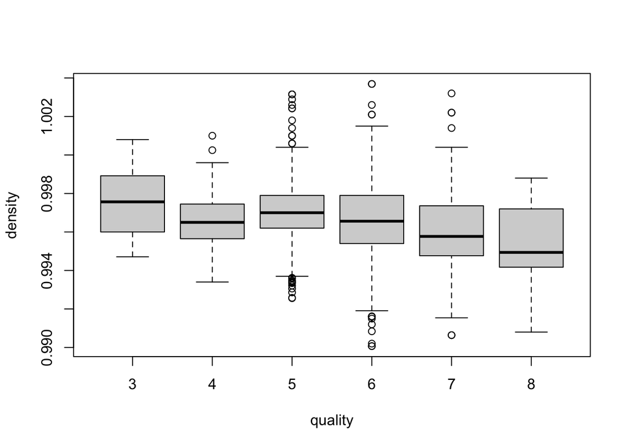

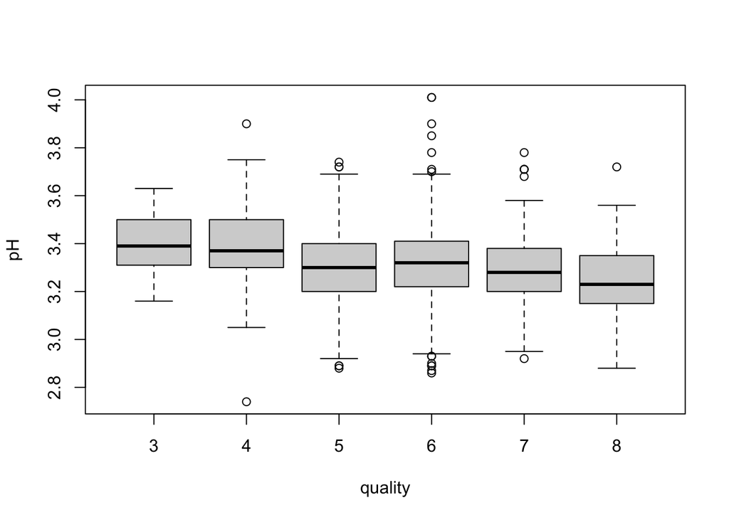

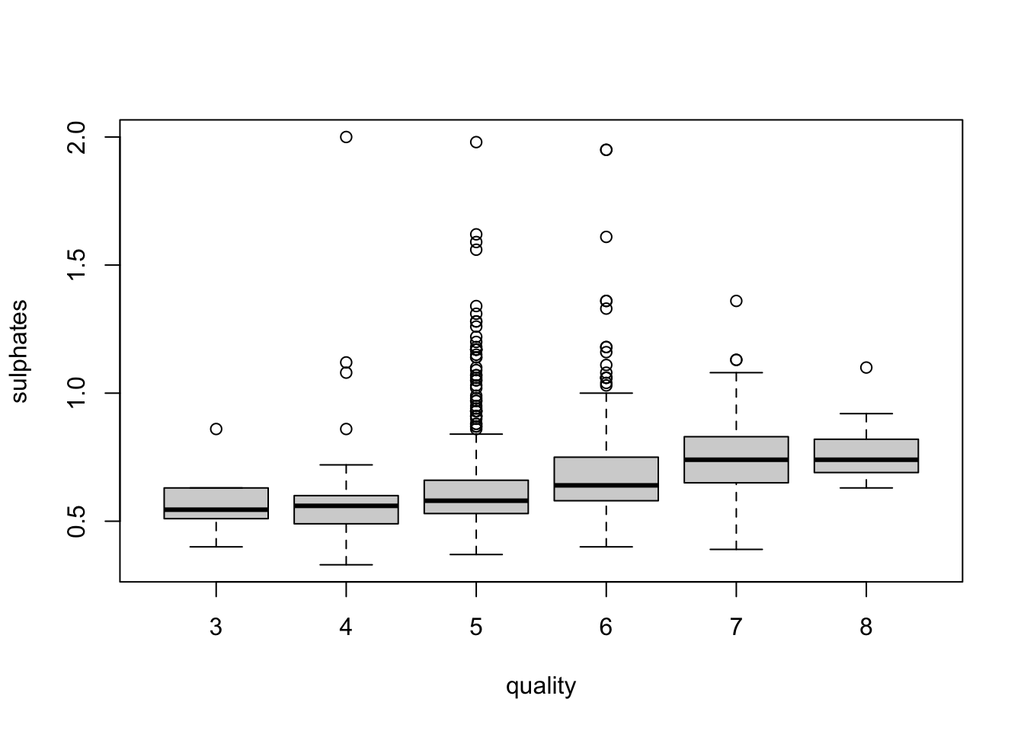

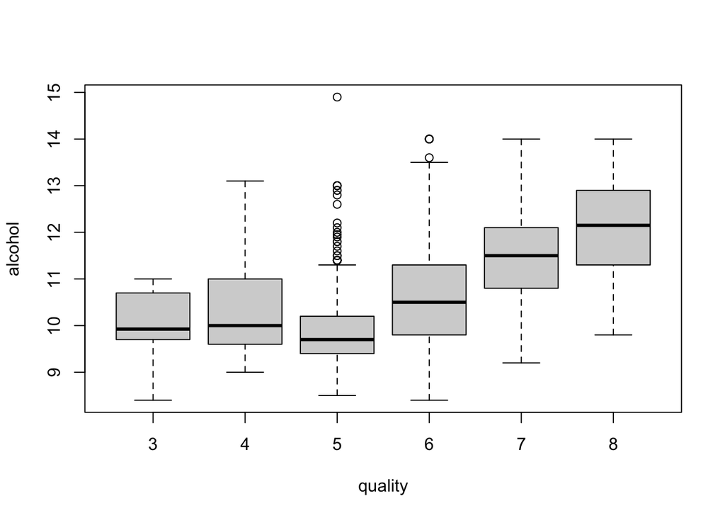

```r
# table(wine_df$quality)
#
# prop.table(table(wine_df$quality))
#
# barplot(prop.table(table(wine_df$quality)))
#
# pairs(quality ~ density + pH, data = wine_df)
#
# boxplot(density ~ quality, data = wine_df)

all_col <- colnames(wine_df)
all_formula_strings <- paste0(all_col, ' ~ quality')
col_names_length <- length(all_col)
for (i in all_formula_strings[1:col_names_length - 1]) {
  boxplot(as.formula(i), data = wine_df)
}
```